# Chapter 7 — Comparing Three or More Groups (R companion)

R/tidyverse translation of *Understanding Data by Alan Garfinkel and Yina Guo

Adrian Soto-Mota, MD, PhD, FACP.

2026-04-24

# Orientation

Chapter 7 (book pp. 285–365) extends the two-group toolkit to many groups, carefully navigating the **multiple-testing trap** (“green jelly beans”). It introduces the **omnibus F-test** built by resampling, then BH-corrected post-hoc pairwise comparisons. The book contains explicit Python snippets in **§7.10** (“How does resampling compare to formula-based ANOVA”, pp. 364–365), reproduced in-place below.

# §7.1 — Data *(book §7.1 “Visualizing the data and choosing the measures”, p. 287)*

Five groups, 15 observations each. One group (E) has a real shift.

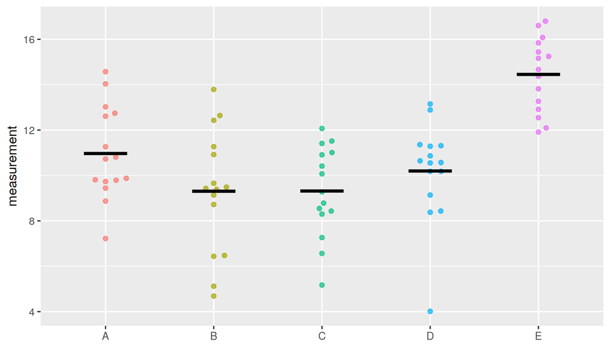

```r
make_group <- function(n, mu, sigma) rnorm(n, mean = mu, sd = sigma)

df <- tibble(
  group = rep(LETTERS[1:5], each = 15),
  y     = c(make_group(15, 10, 2),
            make_group(15, 10, 2),
            make_group(15, 10, 2),
            make_group(15, 10, 2),
            make_group(15, 14, 2))   # E is 2 SDs above the rest
)

ggplot(df, aes(group, y, color = group)) +
  geom_beeswarm(alpha = 0.7, cex = 2) +
  stat_summary(fun = mean, geom = "crossbar",
               width = 0.4, color = "black") +
  theme(legend.position = "none") +
  labs(x = NULL, y = "measurement")
```

# §7.2 — Why not “just run pairwise t-tests”? *(book p. 292; “Green jelly beans” p. 293)*

With 5 groups there are `5 choose 2 = 10` pairs. At α = 0.05, the chance of at least one false positive under a global null is **1 − 0.95¹⁰ ≈ 40 %**.

```r
n_pairs <- choose(5, 2)
1 - (1 - 0.05)^n_pairs
```

```
## [1] 0.4012631
```

**Simulate the “green jelly beans” fallacy:** generate 5 groups with the same mean, do all 10 pairwise tests, see how often at least one is “significant”.

```r
simulate_pairwise <- function(n_per_group = 15, n_groups = 5) {
  d <- tibble(
    group = rep(LETTERS[1:n_groups], each = n_per_group),
    y     = rnorm(n_per_group * n_groups)           # All from the SAME population
  )
  pairs <- combn(LETTERS[1:n_groups], 2, simplify = FALSE)
  ps <- map_dbl(pairs, \(p) {
    t.test(d$y[d$group == p[1]], d$y[d$group == p[2]])$p.value
  })
  min(ps) < 0.05   # TRUE means at least one "significant" pair
}

n_sim <- 2000
mean(replicate(n_sim, simulate_pairwise()))   # ≈ 0.4
```

```
## [1] 0.2835
```

# §7.3 — Omnibus test by resampling *(book p. 296)*

The chapter uses an F-like statistic — the ratio of between-group variability to within-group variability — and shuffles group labels to build the null.

```r
# Observed F
obs_F <- summary(aov(y ~ group, data = df))[[1]][["F value"]][1]
obs_F
```

```
## [1] 14.85131
```

```r
# Null F distribution by label permutation
n_sim <- 5000
null_F <- numeric(n_sim)
for (i in seq_len(n_sim)) {
  shuffled <- df |> mutate(group = sample(group))  # same y, reshuffled labels
  null_F[i] <- summary(aov(y ~ group, data = shuffled))[[1]][["F value"]][1]
}

p_value_omni <- mean(null_F >= obs_F)
p_value_omni
```

```
## [1] 0
```

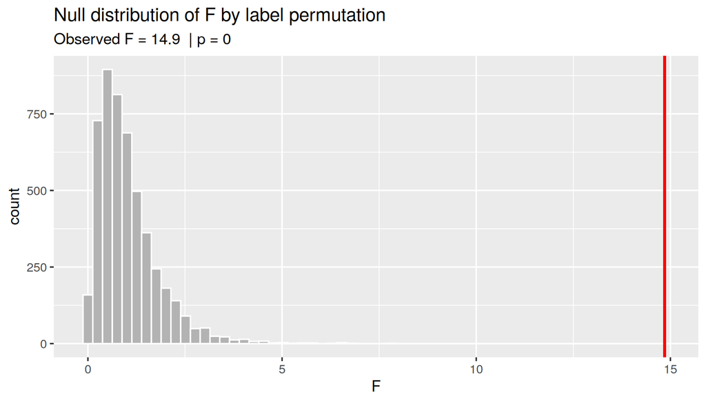

```r
tibble(F = null_F) |>
  ggplot(aes(F)) +
  geom_histogram(bins = 60, fill = "grey70", color = "white") +
  geom_vline(xintercept = obs_F, color = "red", linewidth = 1) +
  labs(title = "Null distribution of F by label permutation",
       subtitle = paste("Observed F =", signif(obs_F, 3),
                        " | p =", signif(p_value_omni, 3)))
```

**Compare to the classical F-test.** From book §7.10 “How does resampling compare to formula-based ANOVA, when the assumptions of traditional ANOVA are met?”, p. 364:

> ```
> >>> from scipy.stats import f_oneway
> >>> f_oneway(A, B, C)
> ```

R equivalent (identical calculation):

```r
# Book p. 364 Python snippet was:
#   >>> from scipy.stats import f_oneway
#   >>> f_oneway(A, B, C)
# R equivalent:
oneway.test(y ~ group, data = df, var.equal = TRUE)
```

```
##
##  One-way analysis of means
##
## data:  y and group
## F = 14.851, num df = 4, denom df = 70, p-value = 7.803e-09
```

```r
summary(aov(y ~ group, data = df))
```

```
##             Df Sum Sq Mean Sq F value  Pr(>F)
## group        4  272.2   68.06   14.85 7.8e-09 ***
## Residuals   70  320.8    4.58
## ---
## Signif. codes:  0 '***' 0.001 '**' 0.01 '*' 0.05 '.' 0.1 ' ' 1
```

Permutation and formula give almost identical p-values.

## Does the omnibus test fix the green-jelly-beans problem?

```r
# Re-run the null simulation: omnibus-only, no pairwise tests
false_positive_rate <- mean(replicate(n_sim, {
  d <- tibble(group = rep(LETTERS[1:5], each = 15),
              y     = rnorm(75))
  p <- summary(aov(y ~ group, data = d))[[1]][["Pr(>F)"]][1]
  p < 0.05
}))
false_positive_rate  # ≈ 0.05, as it should be
```

```
## [1] 0.05
```

Yes. The omnibus test maintains the intended 5 % rate under a true null.

# §7.4–7.5 — Post-hoc pairwise comparisons with BH correction *(book pp. 311, 318)*

**If and only if the omnibus is significant**, proceed to pairwise tests, then adjust for multiple testing. The chapter recommends **Benjamini-Hochberg (FDR)** over Bonferroni as a better trade-off of false discovery and power.

```r
# Raw pairwise p-values
pairs <- combn(LETTERS[1:5], 2, simplify = FALSE)
raw_p <- map_dbl(pairs, \(p) {
  t.test(df$y[df$group == p[1]], df$y[df$group == p[2]])$p.value
})

# BH adjustment (chapter: "built into Python and almost all other languages")
# R equivalent:
adj_p_bh  <- p.adjust(raw_p, method = "BH")

# Bonferroni: multiply by the number of tests (most conservative)
adj_p_bon <- p.adjust(raw_p, method = "bonferroni")

results <- tibble(
  pair   = map_chr(pairs, paste, collapse = "-"),
  raw_p  = raw_p,
  BH     = adj_p_bh,
  Bonf   = adj_p_bon
)
results |> arrange(raw_p)
```

```
## # A tibble: 10 x 4
##    pair         raw_p          BH        Bonf
##    <chr>        <dbl>       <dbl>       <dbl>
##  1 C-E   0.0000000259 0.000000259 0.000000259
##  2 B-E   0.00000202   0.00000700  0.0000202
##  3 D-E   0.00000210   0.00000700  0.0000210
##  4 A-E   0.0000206    0.0000514   0.000206
##  5 A-C   0.0334       0.0667      0.334
##  6 A-B   0.0695       0.116       0.695
##  7 C-D   0.258        0.367       1
##  8 A-D   0.326        0.367       1
##  9 B-D   0.330        0.367       1
## 10 B-C   0.991        0.991       1
```

All E-vs-other pairs are significant after BH adjustment. The other 6 pairs (among A–D) are correctly non-significant.